# Canine Skin Microbiome: Microbial Diversity Analysis

Spencer Toth

2026-07-05

**Null Hypothesis:** No change-point in bray-curtis dissimilarity between paired control and surgical sites of dogs before surgery.

**Description:** Each dog has its own control prior to surgery as well as a control site that did not undergo surgery. We will fit a change-point model of the dissimilarity (using Bray-Curtis) between the surgical site and control skin site on each of the dogs in the study.

**References:** Longitudinal profiling of the microbiome at four body sites reveals core stability and individualized dynamics during health and disease (Cell Host Microbe - April 2025) https://pmc.ncbi.nlm.nih.gov/articles/PMC11022754/ Metagenomic characterisation of canine skin reveals a core healthy skin microbiome (Nature - August 2024) https://www.nature.com/articles/s41598-024-63999-5 Cutaneous Microbiome Profiles Following Chlorhexidine Treatment in a 72-Hour Daily Follow-Up Paired Design: a Pilot Study (ASM - June 2022) https://journals.asm.org/doi/full/10.1128/spectrum.01753-21

# Load files

```r
library(knitr)
library(FSA)
library(tidyverse)
library(vegan)
library(phyloseq)
library(ggplot2)
library(ggtree)
library(scales)
library(RColorBrewer)
library(segmented)
library(stringr)
library(pairwiseAdonis)
library(ggpubr)
library(changepoint)
library(dplyr)
library(lme4)
library(emmeans)
library(nortest)
library(mcp)
library(purrr)
```

### Create phyloseq objects

1. Load each output file for each sequencing run processed in decontam as phyloseq object
2. grep Skin “Location_Type” (filter out negative non-skin controls)
3. Merge all phyloseq objects for downstream analysis

```r
load("../02_output_files/01_filtered_ASV_tables/CH1_filtered_canine_skin_microbiome.rda")

ps1 <- phyloseq(otu_table(ASV_feature_table_decontam, taxa_are_rows=FALSE),
               sample_data(sample_metadata_decontam),
               tax_table(taxa_annotations_decontam))
 ps1 <- prune_samples(
  grepl("Skin", sample_data(ps1)$Location_Type),
  ps1
)
load("../02_output_files/01_filtered_ASV_tables/CH2_filtered_canine_skin_microbiome.rda")

ps2 <- phyloseq(otu_table(ASV_feature_table_decontam, taxa_are_rows=FALSE),
               sample_data(sample_metadata_decontam),
               tax_table(taxa_annotations_decontam))
 ps2 <- prune_samples(
  grepl("Skin", sample_data(ps2)$Location_Type),
  ps2
)
load("../02_output_files/01_filtered_ASV_tables/CH3_filtered_canine_skin_microbiome.rda")

ps3 <- phyloseq(otu_table(ASV_feature_table_decontam, taxa_are_rows=FALSE),
               sample_data(sample_metadata_decontam),
               tax_table(taxa_annotations_decontam))
 ps3 <- prune_samples(
  grepl("Skin", sample_data(ps3)$Location_Type),
  ps3
)
load("../02_output_files/01_filtered_ASV_tables/CH4_filtered_canine_skin_microbiome.rda")

ps4 <- phyloseq(otu_table(ASV_feature_table_decontam, taxa_are_rows=FALSE),
               sample_data(sample_metadata_decontam),
               tax_table(taxa_annotations_decontam))
  ps4 <- prune_samples(
  grepl("Skin", sample_data(ps4)$Location_Type),
  ps4
)
ps <- merge_phyloseq(ps1, ps2, ps3, ps4)
ps <- prune_samples(
  grepl("Skin", sample_data(ps)$Location_Type),
  ps
)
```

# Bioinformatics Analysis

## Taxa-Based Filtering

### Remove uncharacterized ASVs

```r
otu_matrix <- as(otu_table(ps), "matrix")

# Get total ASV count per Sample_Plate
# Sample_Plate indicates sequencing run
total_asvs_per_plate <- data.frame(
  Sample_Plate = sample_data(ps)$Sample_Plate,
  as.data.frame(otu_matrix)
) %>%
  group_by(Sample_Plate) %>%
  summarise(
    Total_ASVs = sum(colSums(across(-where(is.character))) > 0),
    .groups = "drop"
  )

unknown_asvs <- rownames(tax_table(ps))[
  is.na(tax_table(ps)[, "Phylum"]) | tax_table(ps)[, "Phylum"] %in% c("", "uncharacterized")
]


otu_unknown <- otu_matrix[, unknown_asvs, drop = FALSE]

# Provide summary for uncharacterized ASV count per seq. run
out <- data.frame(
  Sample_Plate = sample_data(ps)$Sample_Plate,
  as.data.frame(otu_unknown)
) %>%
  group_by(Sample_Plate) %>%
  summarise(
    Unknown_ASVs_Count = sum(colSums(across(-where(is.character))) > 0),
    .groups = "drop"
  ) %>%
  left_join(total_asvs_per_plate, by = "Sample_Plate") %>%
  mutate(
    Percent_Removed = 100 * Unknown_ASVs_Count / Total_ASVs
  )
print(out)
```

```
## # A tibble: 4 × 4
##   Sample_Plate Unknown_ASVs_Count Total_ASVs Percent_Removed
##   <chr>                     <int>      <int>           <dbl>
## 1 CHLib1                      125       4254            2.94
## 2 CHLib2                       39       3154            1.24
## 3 CHLib3                      151       8778            1.72
## 4 CHLib4                      137       7630            1.80
```

```r
# Subset phyloseq object for downstream analysis
ps_1 <- subset_taxa(ps, !is.na(Phylum) & !Phylum %in% c("", "uncharacterized"))
```

### Check for low-prevalence taxa

No phylum were removed.

```r
# Compute prevalence for each ASV
prevdf = apply(X = otu_table(ps_1),
               MARGIN = ifelse(taxa_are_rows(ps_1), yes = 1, no = 2),
               FUN = function(x){sum(x > 0)})

# Add taxa and total read counts to prevalence df
prevdf = data.frame(Prevalence = prevdf,
                    TotalAbundance = taxa_sums(ps_1),
                    tax_table(ps_1))

# Are there phyla that are comprised of mostly low-prevalence features?
# Compute per Phylum: Average number of ASVs and total number of ASVs across samples
phylum_summary <- plyr::ddply(prevdf, "Phylum", function(df1){
  cbind(mean(df1$Prevalence), sum(df1$Prevalence))
})
colnames(phylum_summary) <- c("Phylum", "Mean_Prevalence", "Sum_Prevalence")

# Phyla by Total ASV Prevalence
phylum_summary_sorted <- phylum_summary[order(-phylum_summary$Sum_Prevalence), ]
print(phylum_summary_sorted, row.names = FALSE)
```

```
##                      Phylum Mean_Prevalence Sum_Prevalence
##              Pseudomonadota        29.50044         134581
##                   Bacillota        30.86142         120699
##              Actinomycetota        29.62878          88116
##                Bacteroidota        23.91012          44162
##             Cyanobacteriota        26.81629          16787
##             Acidobacteriota        16.02006           5591
##               Chloroflexota        16.17131           4059
##              Fusobacteriota        29.17293           3880
##           Verrucomicrobiota        15.01117           2687
##                 Myxococcota        12.48387           2322
##             Planctomycetota        10.61494           1847
##            Campylobacterota        29.63830           1393
##                Deinococcota        23.87500           1337
##             Gemmatimonadota        12.80645           1191
##     Thermodesulfobacteriota        21.10714           1182
##             Patescibacteria        26.50000           1113
##            Bdellovibrionota        12.05714            844
##               Spirochaetota        32.62500            783
##              Armatimonadota        10.75862            312
##              Thermoproteota        22.21429            311
##            Abditibacteriota        14.85000            297
##     Candidatus Kapabacteria        23.66667            213
##                Nitrospirota        22.42857            157
##           Methanobacteriota        48.33333            145
##              Fibrobacterota        20.00000            120
##            Thermoplasmatota        31.00000             93
##                 Sumerlaeota        13.33333             80
##                 Chlamydiota         9.12500             73
##                Synergistota        24.00000             72
##             Elusimicrobiota        10.00000             60
##            Latescibacterota        10.60000             53
##           Methylomirabilota         9.00000             45
##               Rhodothermota         7.50000             45
##           Entotheonellaeota        10.50000             42
##                Dependentiae         7.50000             30
##                       NB1-j         8.50000             17
##              Halobacteriota        16.00000             16
##  Candidatus Eremiobacterota         8.00000              8
##        Candidatus Kryptonia         8.00000              8
##              Incertae Sedis         8.00000              8
```

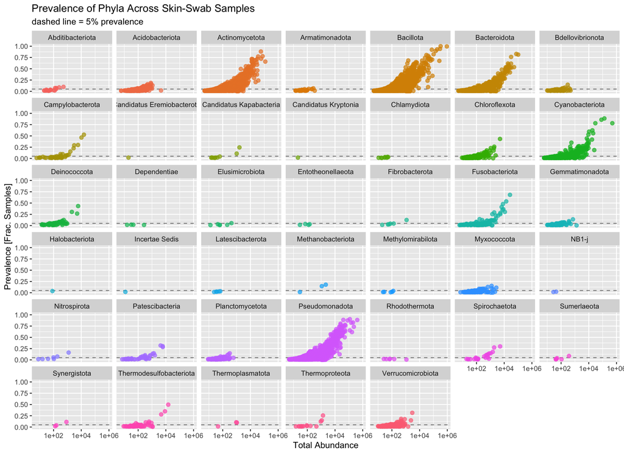

```r
ggplot(prevdf, aes(TotalAbundance, Prevalence / nsamples(ps_1),color=Phylum)) +
  ggtitle("Prevalence of Phyla Across Skin-Swab Samples", subtitle="dashed line = 5% prevalence") +
  geom_hline(yintercept = 0.05, alpha = 0.5, linetype = 2) +  geom_point(size = 2, alpha = 0.7) +
  scale_x_log10() +  xlab("Total Abundance") + ylab("Prevalence [Frac. Samples]") +
  facet_wrap(~Phylum) + theme(legend.position="none")
```

### Total Reads + ASVs per Individual and Sequencing Run

```r
out_dir <- "../02_output_files/02_image_files"

# Get reads and metadata per sample
reads_per_sample <- sample_sums(ps_1)
md <- as(sample_data(ps_1), "data.frame")

sample_names_ps <- sample_names(ps_1)

# Ensure sample order matches
if (!all(sample_names_ps == rownames(md))) {
  md <- md[sample_names_ps, ]
}

# Create dataframe with sample-level stats
df <- data.frame(
  sample = sample_names_ps,
  total_reads = reads_per_sample,
  Sample_Plate = md$Sample_Plate,
  Individual = md$Individual,
  stringsAsFactors = FALSE
)

# Calculate total reads and ASVs per sample and add to metadata
otu <- otu_table(ps_1)
if (taxa_are_rows(otu)) {
  total_asvs <- colSums(otu > 0)
} else {
  total_asvs <- rowSums(otu > 0)
}

total_reads <- sample_sums(ps_1)

md$total_asv <- total_asvs
md$total_reads <- total_reads

sample_data(ps_1) <- sample_data(md)

md <- md %>%
  arrange(Surgery_Type, Individual) %>%
  mutate(Individual = factor(Individual, levels = unique(Individual)))

my_cols <- colorRampPalette(brewer.pal(8, "Dark2"))(20)

# Aggregate reads and ASVs per Individual
by_ind <- aggregate(
  cbind(total_reads, total_asv) ~ Individual + Sample_Plate,
  data = md,
  FUN = sum
)

print(by_ind)
```

```
##    Individual Sample_Plate total_reads total_asv
## 1       CH001       CHLib1      405527     14284
## 2       CH005       CHLib1      511922     15746
## 3       CH006       CHLib1      746751     12628
## 4       CH008       CHLib1      669721     13763
## 5       CH012       CHLib1      852943      9993
## 6       CH003       CHLib2      380100      8486
## 7       CH011       CHLib2      492847      9037
## 8       CH013       CHLib2     1086973     12120
## 9       CH014       CHLib2     1269282     14774
## 10      CH016       CHLib2      994068     13810
## 11      CH009       CHLib3      788789     21126
## 12      CH020       CHLib3      347338     39922
## 13      CH022       CHLib3      519229     48533
## 14      CH024       CHLib3      680241     46112
## 15      CH025       CHLib3     1342971     27728
## 16      CH017       CHLib4      465532     19451
## 17      CH018       CHLib4      991615     22964
## 18      CH019       CHLib4      992998     47348
## 19      CH021       CHLib4     1262083     21149
## 20      CH023       CHLib4     1194380     15805
```

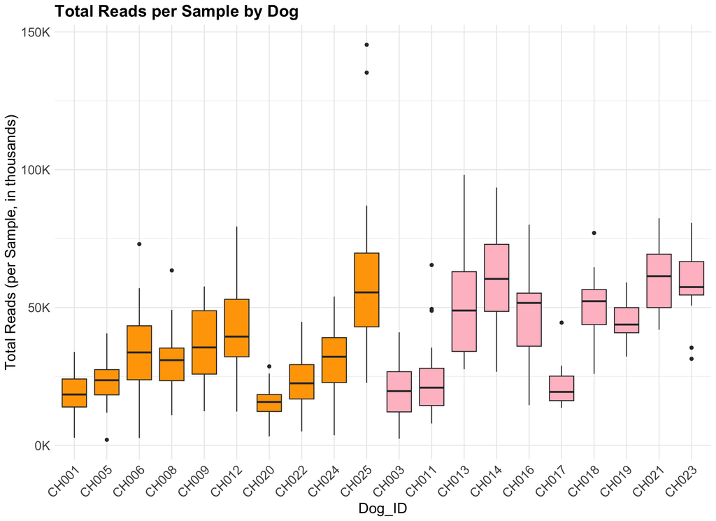

```r
# Boxplot for total reads by Individual (each point = one sample)
p_reads <- ggplot(md, aes(x = Individual, y = total_reads, fill = Surgery_Type)) +
  geom_boxplot()  +
  scale_fill_manual(values = c(
    "Abdomen" = "orange",
    "Stifle" = "pink"
  )) +
  scale_y_continuous(
    labels = function(x) paste0(x / 1000, "K"),
    name = "Total Reads (per Sample, in thousands)"
  ) +
  labs(
    title = "Total Reads per Sample by Dog",
    x = "Dog_ID"
  ) +
  theme_minimal()+
  theme(
    axis.text.x = element_text(angle = 45, hjust = 1, size = 14),
    axis.text.y = element_text(size = 14),
    axis.title.x = element_text(size = 16),
    axis.title.y = element_text(size = 16),
    plot.title = element_text(size = 18, face = "bold"),
    legend.position = "none"
  )

p_reads
```

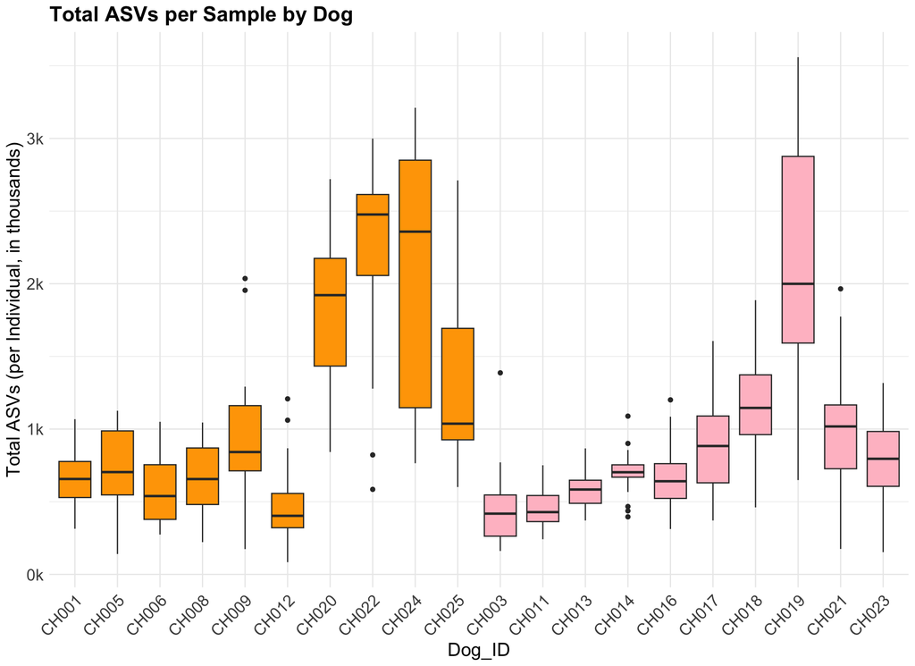

```r
out_reads <- paste0(out_dir, "/total_reads_by_individual.png")
ggplot2::ggsave(out_reads, p_reads, width = 8, height = 6)


# Boxplot for total ASVs by Individual (each point = one sample)
p_asv <- ggplot(md, aes(x = Individual, y = total_asv, fill = Surgery_Type)) +
  geom_boxplot() +
  scale_fill_manual(values = c(
    "Abdomen" = "orange",
    "Stifle" = "pink"
  )) +
  scale_y_continuous(
    labels = function(x) paste0(x / 1000, "k"),
    name = "Total ASVs (per Individual, in thousands)"
  ) +
  labs(
    title = "Total ASVs per Sample by Dog",
    x = "Dog_ID"
  ) +
  theme_minimal()+
  theme(
    axis.text.x = element_text(angle = 45, hjust = 1, size = 14),
    axis.text.y = element_text(size = 14),
    axis.title.x = element_text(size = 16),
    axis.title.y = element_text(size = 16),
    plot.title = element_text(size = 18, face = "bold"),
    legend.position = "none"
  )
p_asv
```

```r
out_asv <- paste0(out_dir, "/total_asvs_by_individual.png")
ggplot2::ggsave(out_asv, p_asv, width = 8, height = 6)


# Aggregate reads and ASVs per Seq Run
by_plate <- aggregate(
  cbind(total_reads, total_asv) ~ Sample_Plate,
  data = md,
  FUN = sum
)

print(by_plate)
```

```
##   Sample_Plate total_reads total_asv
## 1       CHLib1     3186864     66414
## 2       CHLib2     4223270     58227
## 3       CHLib3     3678568    183421
## 4       CHLib4     4906608    126717
```

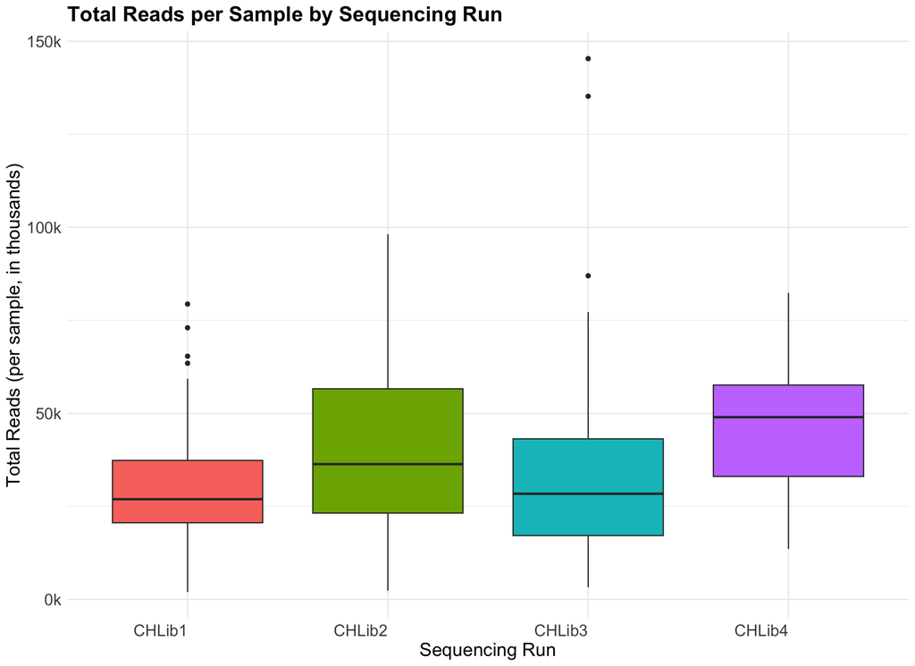

```r
# Boxplot for total reads by Sample_Plate
p_reads <- ggplot(md, aes(x = Sample_Plate, y = total_reads, fill = Sample_Plate)) +
  geom_boxplot() +
  scale_y_continuous(
    labels = function(x) paste0(x / 1000, "k"),
    name = "Total Reads (per sample, in thousands)"
  ) +
  labs(
    title = "Total Reads per Sample by Sequencing Run",
    x = "Sequencing Run"
  ) +
  theme_minimal()+
  theme(
    axis.text.x = element_text(angle = 0, hjust = 1, size = 14),
    axis.text.y = element_text(size = 14),
    axis.title.x = element_text(size = 16),
    axis.title.y = element_text(size = 16),
    plot.title = element_text(size = 18, face = "bold"),
    legend.position = "none"
  )

out_reads <- paste0(out_dir, "/total_reads_by_sample_plate.png")
ggplot2::ggsave(out_reads, p_reads, width = 8, height = 6)
p_reads
```

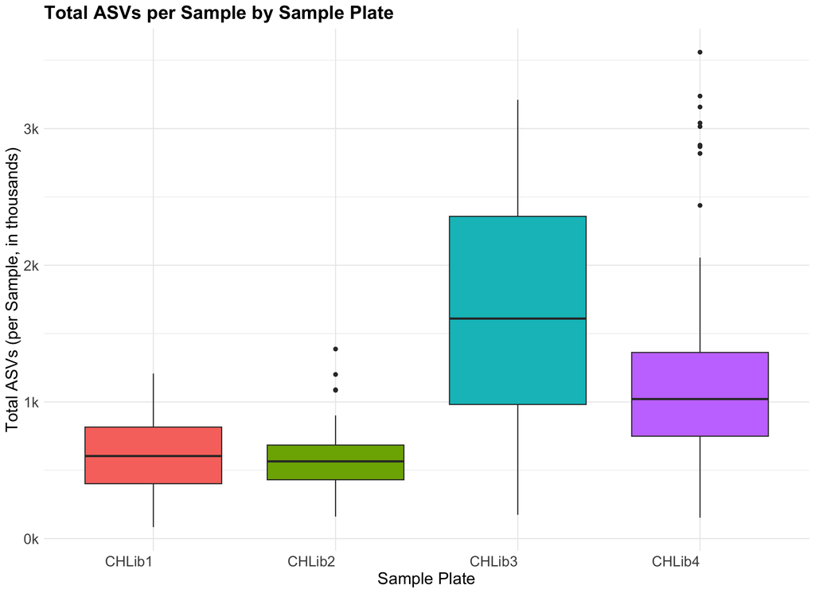

```r
# Boxplot for total ASVs by Sample_Plate
p_asv <- ggplot(md, aes(x = Sample_Plate, y = total_asv, fill = Sample_Plate)) +
  geom_boxplot() +
  scale_y_continuous(
    labels = function(x) paste0(x / 1000, "k"),
    name = "Total ASVs (per Sample, in thousands)"
  ) +
  labs(
    title = "Total ASVs per Sample by Sample Plate",
    x = "Sample Plate"
  ) +
  theme_minimal()+
  theme(
    axis.text.x = element_text(angle = 0, hjust = 1, size = 14),
    axis.text.y = element_text(size = 14),
    axis.title.x = element_text(size = 16),
    axis.title.y = element_text(size = 16),
    plot.title = element_text(size = 18, face = "bold"),
    legend.position = "none"
  )

p_asv
```

```r
out_asv <- paste0(out_dir, "/total_asvs_by_sample_plate.png")
ggplot2::ggsave(out_asv, p_asv, width = 8, height = 6)
```

## Sequencing Run Batch Effect

### PERMANOVA Test

**Notes:**

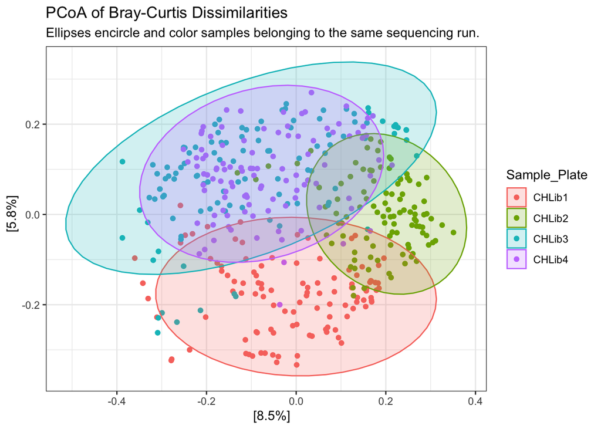

```r
# Extract sample data
metadata <- as(sample_data(ps_1), "data.frame")

# Normalization using relative abundances
ps_rel_1 <- transform_sample_counts(ps_1, function(x) x / sum(x))
individual_list <- unique(sample_data(ps_rel_1)$Individual)

bray_dist <- phyloseq::distance(ps_rel_1, method = "bray")

set.seed(100)
bray_pcoa <- ordinate(ps_rel_1, method = "PCoA", distance =  bray_dist)
p1 <- plot_ordination(ps_rel_1, bray_pcoa, color = "Sample_Plate")


p1 + ggtitle("PCoA of Bray-Curtis Dissimilarities", subtitle = "Ellipses encircle and color samples belonging to the same sequencing run.") +
  geom_point(size = 1.5) +
  theme_bw() +
  stat_ellipse(aes(fill = Sample_Plate, group = Sample_Plate), alpha = 0.2, geom = "polygon")
```

```r
bray_matrix <- as.matrix(bray_dist)

# PERMANOVA test
set.seed(100)
adonis2(bray_matrix ~ Sample_Plate + Dog_ID, data = metadata, permutations = 999, by = "terms")
```

```
## Permutation test for adonis under reduced model
## Terms added sequentially (first to last)
## Permutation: free
## Number of permutations: 999
##
## adonis2(formula = bray_matrix ~ Sample_Plate + Dog_ID, data = metadata, permutations = 999, by = "terms")
##               Df SumOfSqs      R2       F Pr(>F)
## Sample_Plate   3   16.244 0.10556 20.6450  0.001 ***
## Dog_ID        16   31.421 0.20418  7.4873  0.001 ***
## Residual     405  106.225 0.69026
## Total        424  153.890 1.00000
## ---
## Signif. codes:  0 '***' 0.001 '**' 0.01 '*' 0.05 '.' 0.1 ' ' 1
```

### Paired-Only timepoint samples

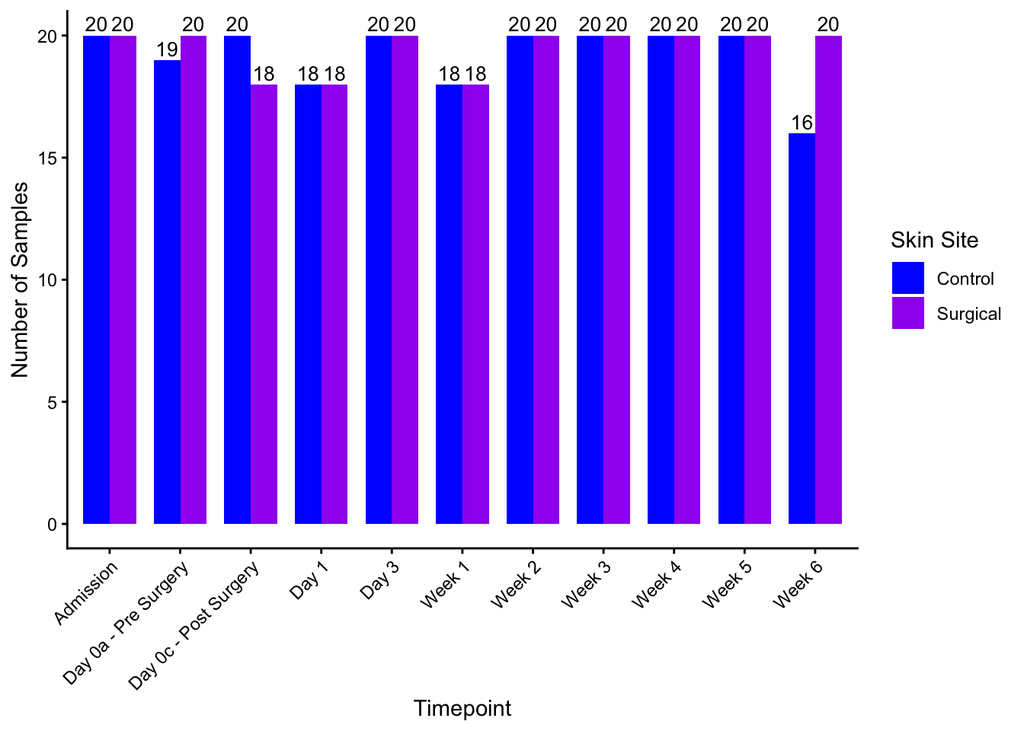

```r
# Set timepoint order
day_levels <- c(
  "Admission",
  "Day 0a - Pre Surgery",
  "Day 0c - Post Surgery",
  "Day 1",
  "Day 3",
  "Week 1",
  "Week 2",
  "Week 3",
  "Week 4",
  "Week 5",
  "Week 6"
)
metadata$Day_Order <- factor(metadata$Day_Order, levels = day_levels)
metadata$Sample_Site <- factor(metadata$Sample_Site, levels = c("Control", "Surgical"))

#Count skin samples across timepoints
count_df <- metadata %>%
  dplyr::select(Day_Order, Sample_Site, Sample_Unique) %>%
  distinct() %>%
  group_by(Day_Order, Sample_Site) %>%
  summarise(n = n(), .groups = "drop")


count_df$Day_Order <- factor(count_df$Day_Order, levels = day_levels)
count_df$Sample_Site <- factor(count_df$Sample_Site, levels = c("Control", "Surgical"))

p <- ggplot(count_df, aes(x = Day_Order, y = n, fill = Sample_Site)) +
  geom_col(position = position_dodge(width = 0.75), width = 0.75) +
  geom_text(
    aes(label = n),
    position = position_dodge(width = 0.75),
    vjust = -0.3,
    size = 3.5
  ) +
  scale_fill_manual(values = c("Control" = "blue", "Surgical" = "purple")) +
  labs(
    x = "Timepoint",
    y = "Number of Samples",
    fill = "Skin Site"
  ) +
  theme_classic() +
  theme(
    axis.text.x = element_text(angle = 45, hjust = 1),
    legend.position = "right"
  )

print(p)
```

```r
# Check which dogs are missing samples (either control or surgical) at each timepoint
missing_sample_unique <- metadata %>%
  group_by(Individual, Day_Order) %>%
  summarise(
    site_absent = if (all(c("Control", "Surgical") %in% Sample_Site)) NA_character_
                  else paste(setdiff(c("Control", "Surgical"), unique(Sample_Site)), collapse = ", "),
    Sample_Unique = paste(sort(unique(Sample_Unique)), collapse = ", "),
    n_sites = n_distinct(Sample_Site),
    .groups = "drop"
  ) %>%
  filter(n_sites < 2) %>%
  dplyr::select(Individual, Day_Order, site_absent, Sample_Unique) %>%
  arrange(Individual, Day_Order)

print(missing_sample_unique)
```

```
## # A tibble: 9 × 4
##   Individual Day_Order             site_absent Sample_Unique
##   <chr>      <fct>                 <chr>       <chr>
## 1 CH003      Day 0c - Post Surgery Surgical    3PostC
## 2 CH008      Week 6                Control     8D42S
## 3 CH011      Week 1                Surgical    11D7C
## 4 CH011      Week 6                Control     11D42S
## 5 CH012      Week 1                Control     12D7S
## 6 CH013      Week 6                Control     13D42S
## 7 CH014      Week 6                Control     14D42S
## 8 CH016      Day 0a - Pre Surgery  Control     16PreS
## 9 CH021      Day 0c - Post Surgery Surgical    21PostC
```

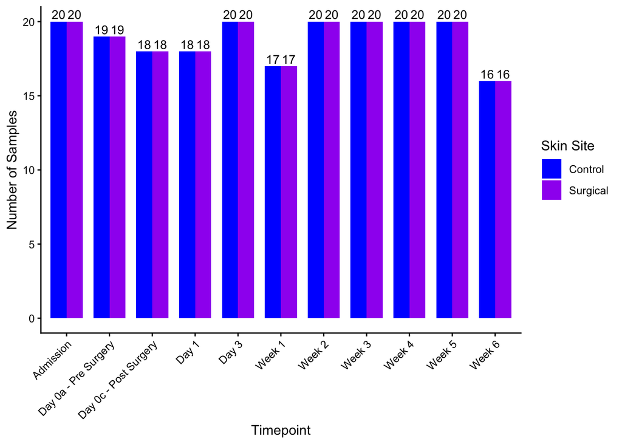

```r
# Keep only samples that have control and surgical at each Day_Order
paired_groups <- metadata %>%
  group_by(Individual, Day_Order) %>%
  summarize(n_sites = n_distinct(Sample_Site), .groups = "drop") %>%
  filter(n_sites == 2) %>%
  transmute(Individual, Day_Order)
paired_sample_data <- metadata %>%
  inner_join(paired_groups, by = c("Individual", "Day_Order"))


# Prune phyloseq object so it only contains these remaining samples
ps_2 <- prune_samples(paired_sample_data$SampleID, ps_1)


# Count unique samples by Day_Order and Sample_Site
count_df <- paired_sample_data %>%
  dplyr::select(Day_Order, Sample_Site, Sample_Unique) %>%
  distinct() %>%
  group_by(Day_Order, Sample_Site) %>%
  summarise(n = n(), .groups = "drop")


count_df$Day_Order <- factor(count_df$Day_Order, levels = day_levels)


count_df$Sample_Site <- factor(count_df$Sample_Site, levels = c("Control", "Surgical"))

# Updated after removing dog-timepoint samples with only one site
p <- ggplot(count_df, aes(x = Day_Order, y = n, fill = Sample_Site)) +
  geom_col(position = position_dodge(width = 0.75), width = 0.75) +
  geom_text(
    aes(label = n),
    position = position_dodge(width = 0.75),
    vjust = -0.3,
    size = 3.5
  ) +
  scale_fill_manual(values = c("Control" = "blue", "Surgical" = "purple")) +
  labs(
    x = "Timepoint",
    y = "Number of Samples",
    fill = "Skin Site"
  ) +
  theme_classic() +
  theme(
    axis.text.x = element_text(angle = 45, hjust = 1),
    legend.position = "right"
  )

print(p)
```

```r
paired_sample_data$Sample_Site <- factor(paired_sample_data$Sample_Site)
paired_sample_data$Dog_ID <- factor(paired_sample_data$Dog_ID)
paired_sample_data$Sample_Plate <- factor(paired_sample_data$Sample_Plate)
paired_sample_data$Collection_Day <- as.numeric(paired_sample_data$Collection_Day)
```

# Statistical Analysis

## Beta & Alpha Diversity

### Shannon Alpha-Diversity

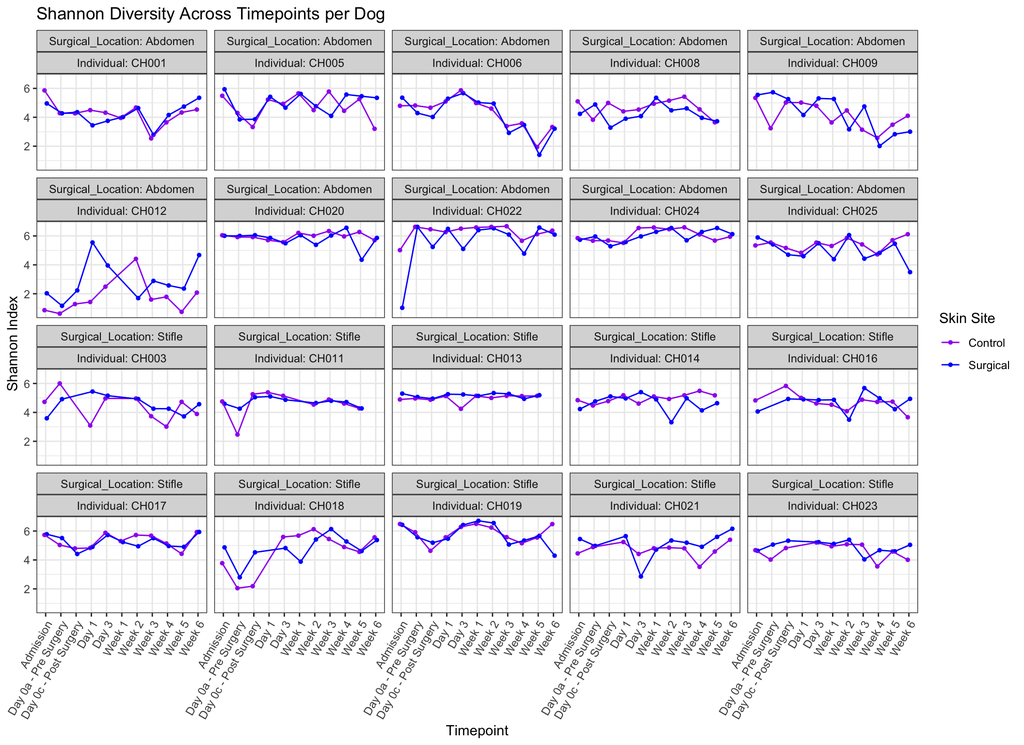

```r
alphadiv_plot_data <- estimate_richness(ps_2, measures = "Shannon") %>%
  rownames_to_column(var = "SampleID") %>%
  left_join(as.data.frame(sample_data(ps_2)), by = "SampleID") %>%
  group_by(Individual) %>%
  mutate(Surgical_Location = Sample_Location[Sample_Site == "Surgical"][1]) %>%
  ungroup() %>%
  mutate(Surgical_Location = factor(Surgical_Location)) %>%
  arrange(Surgical_Location, Individual)
ggplot(alphadiv_plot_data, aes(x = factor(Day_Order), y = Shannon, color = Sample_Site, group = Sample_Site)) +
  geom_point(size = 1, position = position_dodge(width = 0.3)) +
  geom_line(position = position_dodge(width = 0.3)) +
  facet_wrap(
    Surgical_Location ~ Individual,
    labeller = label_both
  ) +
  scale_color_manual(values = c("Control" = "purple", "Surgical" = "blue")) +
  theme_bw() +
  labs(
    title = "Shannon Diversity Across Timepoints per Dog",
    x = "Timepoint",
    y = "Shannon Index",
    color = "Skin Site"
  ) +
  theme(axis.text.x = element_text(angle = 60, hjust = 1))
```

### Bray-Curtis (BC) Dissimilarity

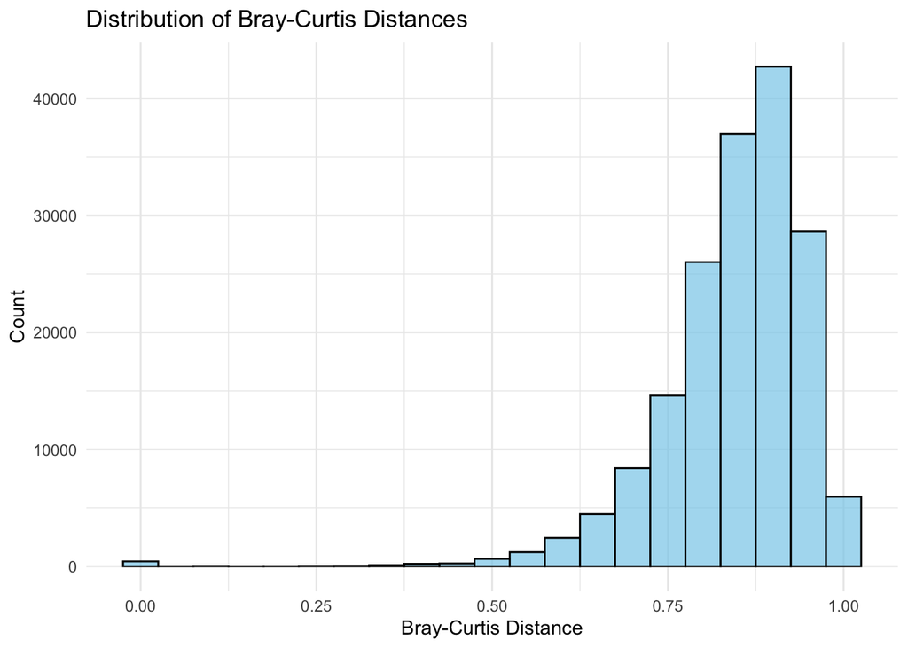

```r
# Normalize read counts by dividing by total read count per sample (relative abundance)
ps_rel_2 <- transform_sample_counts(ps_2, function(x) x / sum(x))
# Generate bray-curtis distance matrix using ASV relative abundances
bray_dist <- phyloseq::distance(ps_rel_2, method = "bray")
bray_dist <- as.matrix(bray_dist)

keep_ids <- paired_sample_data$SampleID
bray_matrix <- bray_dist[keep_ids, keep_ids]

# get vector for histogram
bray_vec <- as.vector(bray_matrix)

# Plot Distribution of Bray-Curtis Distances
histogram_distances <- ggplot(data = data.frame(bray_vec), aes(x = bray_vec)) +
  geom_histogram(binwidth = 0.05, fill = "skyblue", color = "black", alpha = 0.7) +
  theme_minimal() +
  labs(
    title = "Distribution of Bray-Curtis Distances",
    x = "Bray-Curtis Distance",
    y = "Count"
  )

print(histogram_distances)
```

## Change-point analysis

### Bray-curtis matrix transformation

The pairwise Bray-Curtis distances were transformed to improve normality before LMM analysis. An arcsine transformation was ultimately selected, after evaluating eight potential transformations, including log, square-root, arcsine, and ratio-based variants of the original distance values. Normality of the transformed data was assessed using the Anderson–Darling test, and the transformation with the lowest Anderson–Darling statistic was chosen.

```r
### Transformation BC
eps <- 1e-8

x <- as.vector(bray_matrix)


transforms <- list(
  log1p     = log1p(x),
  log_eps   = log(x + eps),
  sqrt      = sqrt(x),
  sqrt1p    = sqrt(x + 1),
  ratio_1px = x / (1 + x),
  ratio_max = x / max(x),
  arcsin_s  = asin(sqrt(x / max(x))),
  arcsin_p  = asin(sqrt(pmin(pmax(x, 0), 1)))
)

res <- data.frame(
  transformation = names(transforms),
  A = sapply(transforms, function(v) ad.test(v)$statistic),
  p = sapply(transforms, function(v) ad.test(v)$p.value)
)

res <- res[order(res$A), ]
res
```

```
##             transformation          A       p
## arcsin_s.A        arcsin_s   874.6257 3.7e-24
## arcsin_p.A        arcsin_p   884.9380 3.7e-24
## ratio_max.A      ratio_max  3397.0354 3.7e-24
## sqrt1p.A            sqrt1p  4125.5514 3.7e-24
## log1p.A              log1p  5044.7951 3.7e-24
## sqrt.A                sqrt  7532.6327 3.7e-24
## ratio_1px.A      ratio_1px  7725.3946 3.7e-24
## log_eps.A          log_eps 49469.1169 3.7e-24
```

```r
best_transform <- res$transformation[1]
best_transform
```

```
## [1] "arcsin_s"
```

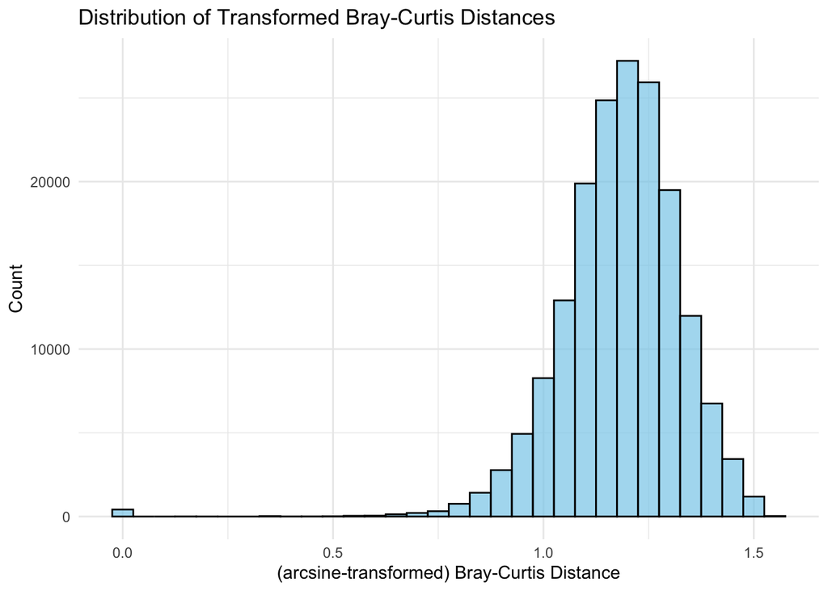

```r
bray_arcsin_s <- asin(sqrt(bray_matrix))

# get vector for histogram
bray_vec <- as.vector(bray_arcsin_s)

# Plot Distribution of Transformed Bray-Curtis Distances
histogram_distances <- ggplot(data = data.frame(bray_vec), aes(x = bray_vec)) +
  geom_histogram(binwidth = 0.05, fill = "skyblue", color = "black", alpha = 0.7) +
  theme_minimal() +
  labs(
    title = "Distribution of Transformed Bray-Curtis Distances",
    x = "(arcsine-transformed) Bray-Curtis Distance",
    y = "Count"
  )

print(histogram_distances)
```

### Fit Linear Mixed Model

We analyzed Bray-Curtis distances between matched control and surgical samples from the same dog and timepoint. This allowed us to model how within-dog control–surgical dissimilarity changed with number of days since surgery while excluding between-dog variation from the response.

**Notes:**

- Fit LMM with subsetted-BC matrix as response, Day_Order (categorical timepoint) as fixed effect, and Dog_ID as random effect.
  - Using LRT, this reduced model was more significant compared to full model where sequencing run was added as an effect
- Contrasts between estimated marginal means of timepoints from model, using Tukey-adjusting p-values:
  - Admission vs Post Surgery: estimate = -0.1668, adj-p = 0.0436
  - Pre Surgery vs Post Surgery: estimate = -0.1749, adj-p = 0.0308
  - Post Surgery vs Week 3: estimate = 0.1709, adj-p = 0.0341
  - Post Surgery vs Week 5: estimate = 0.1737, adj-p = 0.0287
- Estimated marginal means from the mixed model showed a significant increase in BC dissimilarity between control and surgical sites immediately after surgery compared with Admission and Pre-Surgery, followed by a significant decline by Weeks 3 and 5.

```r
bray_arcsin_s <- as.matrix(bray_arcsin_s)
# generate paired-BC matrix where control and surgical samples within dogs are measured
paired_distances <- paired_sample_data %>%
 group_by(Dog_ID, Day_Order) %>%
  summarise(
    Control_Sample = SampleID[Sample_Site == "Control"][1],
    Surgical_Sample = SampleID[Sample_Site == "Surgical"][1],
    Bray_Distance = bray_arcsin_s[Control_Sample, Surgical_Sample],
    Sample_Plate = Sample_Plate[1],
    Day_Order = Day_Order[1],
    Collection_Day = Collection_Day[1],
   .groups = "drop"
  )


print("Group means by Day_Order:")
```

```
## [1] "Group means by Day_Order:"
```

```r
print(paired_distances %>%
  group_by(Day_Order) %>%
  summarise(
    Mean_Bray = mean(Bray_Distance),
    Median_Bray = median(Bray_Distance),
    SD_Bray = sd(Bray_Distance),
    N = n(),
    .groups = "drop"  ) %>%
    arrange(Day_Order)
)
```

```
## # A tibble: 11 × 5
##    Day_Order             Mean_Bray Median_Bray SD_Bray     N
##    <fct>                     <dbl>       <dbl>   <dbl> <int>
##  1 Admission                 0.878       0.902   0.153    20
##  2 Day 0a - Pre Surgery      0.871       0.893   0.210    19
##  3 Day 0c - Post Surgery     1.04        1.07    0.179    18
##  4 Day 1                     0.931       0.909   0.174    18
##  5 Day 3                     0.920       0.925   0.133    20
##  6 Week 1                    0.881       0.907   0.147    17
##  7 Week 2                    0.925       0.919   0.138    20
##  8 Week 3                    0.874       0.935   0.186    20
##  9 Week 4                    0.908       0.909   0.209    20
## 10 Week 5                    0.871       0.922   0.165    20
## 11 Week 6                    0.902       0.881   0.162    16
```

```r
lmer_bray <- lmer(data = paired_distances, Bray_Distance ~ Day_Order + (1 | Dog_ID))

anova(lmer_bray)
```

```
## Analysis of Variance Table
##           npar  Sum Sq  Mean Sq F value
## Day_Order   10 0.45874 0.045874  1.9128
```

```r
summary(lmer_bray)
```

```
## Linear mixed model fit by REML ['lmerMod']
## Formula: Bray_Distance ~ Day_Order + (1 | Dog_ID)
##    Data: paired_distances
##
## REML criterion at convergence: -121.4
##
## Scaled residuals:
##     Min      1Q  Median      3Q     Max
## -3.3234 -0.5640  0.0558  0.5705  2.6621
##
## Random effects:
##  Groups   Name        Variance Std.Dev.
##  Dog_ID   (Intercept) 0.005109 0.07148
##  Residual             0.023982 0.15486
## Number of obs: 208, groups:  Dog_ID, 20
##
## Fixed effects:
##                                 Estimate Std. Error t value
## (Intercept)                     0.878379   0.038139  23.031
## Day_OrderDay 0a - Pre Surgery  -0.008122   0.049655  -0.164
## Day_OrderDay 0c - Post Surgery  0.166754   0.050407   3.308
## Day_OrderDay 1                  0.054663   0.050404   1.084
## Day_OrderDay 3                  0.041987   0.048972   0.857
## Day_OrderWeek 1                 0.006391   0.051234   0.125
## Day_OrderWeek 2                 0.046368   0.048972   0.947
## Day_OrderWeek 3                -0.004118   0.048972  -0.084
## Day_OrderWeek 4                 0.029354   0.048972   0.599
## Day_OrderWeek 5                -0.006930   0.048972  -0.142
## Day_OrderWeek 6                 0.032828   0.052143   0.630
##
## Correlation of Fixed Effects:
##                (Intr) Dy_OrdrDy0-PrS Dy_OrdrDy0c-PS Dy_OD1 Dy_OD3 Dy_OW1 Dy_OW2
## Dy_OrdrDy0-PrS -0.633
## Dy_OrdrDy0c-PS -0.624  0.479
## Day_OrdrDy1    -0.624  0.479          0.472
## Day_OrdrDy3    -0.642  0.493          0.486          0.486
## Day_OrdrWk1    -0.614  0.471          0.466          0.464  0.478
## Day_OrdrWk2    -0.642  0.493          0.486          0.486  0.500  0.478
## Day_OrdrWk3    -0.642  0.493          0.486          0.486  0.500  0.478  0.500
## Day_OrdrWk4    -0.642  0.493          0.486          0.486  0.500  0.478  0.500
## Day_OrdrWk5    -0.642  0.493          0.486          0.486  0.500  0.478  0.500
## Day_OrdrWk6    -0.603  0.463          0.455          0.455  0.470  0.450  0.470
##                Dy_OW3 Dy_OW4 Dy_OW5
## Dy_OrdrDy0-PrS
## Dy_OrdrDy0c-PS
## Day_OrdrDy1
## Day_OrdrDy3
## Day_OrdrWk1
## Day_OrdrWk2
## Day_OrdrWk3
## Day_OrdrWk4     0.500
## Day_OrdrWk5     0.500  0.500
## Day_OrdrWk6     0.470  0.470  0.470
```

```r
confint(lmer_bray)
```

```
##                                      2.5 %     97.5 %
## .sig01                          0.04245190 0.10873940
## .sigma                          0.13666721 0.16729773
## (Intercept)                     0.80517858 0.95158010
## Day_OrderDay 0a - Pre Surgery  -0.10330835 0.08706908
## Day_OrderDay 0c - Post Surgery  0.07005823 0.26335120
## Day_OrderDay 1                 -0.04198181 0.15127015
## Day_OrderDay 3                 -0.05189247 0.13586549
## Day_OrderWeek 1                -0.09185985 0.10458025
## Day_OrderWeek 2                -0.04751121 0.14024675
## Day_OrderWeek 3                -0.09799701 0.08976095
## Day_OrderWeek 4                -0.06452542 0.12323254
## Day_OrderWeek 5                -0.10080875 0.08694921
## Day_OrderWeek 6                -0.06723300 0.13274716
```

```r
# estimated marginal means
emm <- emmeans(lmer_bray, ~ Day_Order)

emm_df <- as.data.frame(emm)[, c("Day_Order", "emmean", "SE", "df", "lower.CL", "upper.CL")]

alpha <- 0.05

contrasts <- data.frame(pairs(emm, Day_Order = "tukey"))

contrasts <- contrasts %>%
  mutate(
    Group1 = case_when(
      str_detect(contrast, "^\\(") ~ str_match(contrast, "^\\((.*?)\\)")[,2],
      TRUE ~ str_match(contrast, "^(.*?) - ")[,2]
    ),
    Group2 = case_when(
      str_detect(contrast, "\\) - \\(") ~ str_match(contrast, "- \\((.*?)\\)$")[,2],
      str_detect(contrast, "^\\(") ~ str_replace(contrast, "^\\(.*?\\) - ", ""),
      TRUE ~ str_match(contrast, "- (.*)$")[,2]
    ),
    Group1 = str_remove_all(str_trim(Group1), "[()]"),
    Group2 = str_remove_all(str_trim(Group2), "[()]")
  )

pairwise_tidy <- contrasts %>%
  filter(!is.na(p.value)) %>%
  mutate(
    Significant = ifelse(p.value <= alpha, "Yes", "No"),
    Stars = case_when(
      p.value <= 0.001 ~ "***",
      p.value <= 0.01  ~ "**",
      p.value <= 0.05  ~ "*",
      p.value <= 0.10 ~ ".",
      TRUE ~ ""
    ),
    p.value = round(p.value, 4) ) %>%
  arrange(p.value)

# Filter out insignificant pairwise results
sig_df <- pairwise_tidy %>%
  filter(Significant == "Yes") %>%
  mutate(
    group1 = Group1,
    group2 = Group2,
    y.position = NA_real_,
    label = Stars
  )
x_levels <- levels(factor(paired_distances$Day_Order))

sig_df <- sig_df %>%
  mutate(
    xmin = match(group1, x_levels),
    xmax = match(group2, x_levels)
  ) %>%
  arrange(p.value) %>%
  mutate(
    y.position = max(paired_distances$Bray_Distance, na.rm = TRUE) +
      seq(0.05, by = 0.05, length.out = n())
  )
print(sig_df)
```

```
##                                           contrast   estimate         SE
## 1                 (Day 0c - Post Surgery) - Week 5  0.1736840 0.05041748
## 2 (Day 0a - Pre Surgery) - (Day 0c - Post Surgery) -0.1748766 0.05109735
## 3                 (Day 0c - Post Surgery) - Week 3  0.1708722 0.05041748
## 4              Admission - (Day 0c - Post Surgery) -0.1667542 0.05041748
##         df   t.ratio p.value                Group1                Group2
## 1 178.6417  3.444916  0.0287 Day 0c - Post Surgery                Week 5
## 2 178.9633 -3.422421  0.0308  Day 0a - Pre Surgery Day 0c - Post Surgery
## 3 178.6417  3.389147  0.0341 Day 0c - Post Surgery                Week 3
## 4 178.6417 -3.307468  0.0436             Admission Day 0c - Post Surgery
##   Significant Stars                group1                group2 y.position
## 1         Yes     * Day 0c - Post Surgery                Week 5   1.449447
## 2         Yes     *  Day 0a - Pre Surgery Day 0c - Post Surgery   1.499447
## 3         Yes     * Day 0c - Post Surgery                Week 3   1.549447
## 4         Yes     *             Admission Day 0c - Post Surgery   1.599447
##   label xmin xmax
## 1     *    3   10
## 2     *    2    3
## 3     *    3    8
## 4     *    1    3
```

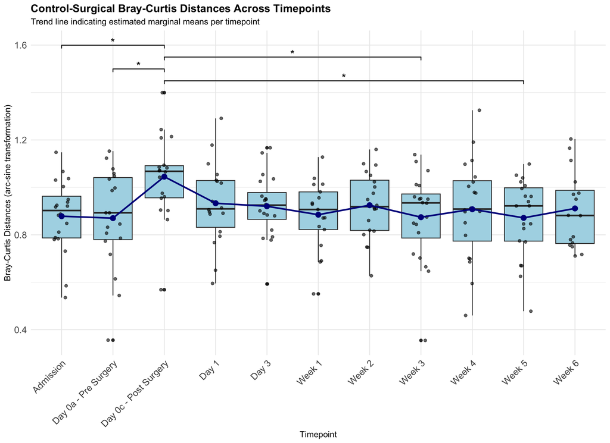

```r
ggplot(paired_distances, aes(x = Day_Order, y = Bray_Distance)) +
  geom_boxplot(fill = "lightblue") +
  geom_jitter(width = 0.15, alpha = 0.6, color = "black") +

 # geom_hline(yintercept = emm_df$emmean[1], linetype = "dashed", color="red") +
  geom_point(data = emm_df, aes(x = Day_Order, y = emmean),
             inherit.aes = FALSE, color = "darkblue", size = 3) +
  geom_line(data = emm_df, aes(x = Day_Order, y = emmean, group = 1),
            inherit.aes = FALSE, color = "darkblue", linewidth = 1) +

  stat_pvalue_manual(
    sig_df,
    label = "label",
    xmin = "xmin",
    xmax = "xmax",
    y.position = "y.position",
    tip.length = 0.01,
    bracket.size = 0.5,
    size = 5
  ) +
  labs(
    title = "Control-Surgical Bray-Curtis Distances Across Timepoints",
    subtitle = "Trend line indicating estimated marginal means per timepoint",
    x = "Timepoint",
    y = "Bray-Curtis Distances (arc-sine transformation)"
  ) +
  theme_minimal() +
  theme(
    plot.title = element_text(size = 14, face = "bold"),
    axis.text.x = element_text(size = 12, angle = 45, hjust = 1),
    axis.text.y = element_text(size = 12)
  )
```

## Differential abundance at breakpoint between stifle control and surgical sites

Wilcoxon signed rank (WSR) test is used to compare relative abundances of species between control and surgical sites at the breakpoint. However surgical sites were on both the abdomen and stifle, while control sites were only the stifle region. The PERMANOVA test shows a significant difference between abdomen and stifle sites potentially suggesting differences in the baseline microbiome of these two regions. Therefore the specific relative abundances of taxa from abdomen samples should not be compared to control stifle samples. Subsequently, the paired samples were subsetted to only within the stifle surgical group.

### Sample Location: PCoA Plot + PERMANOVA test

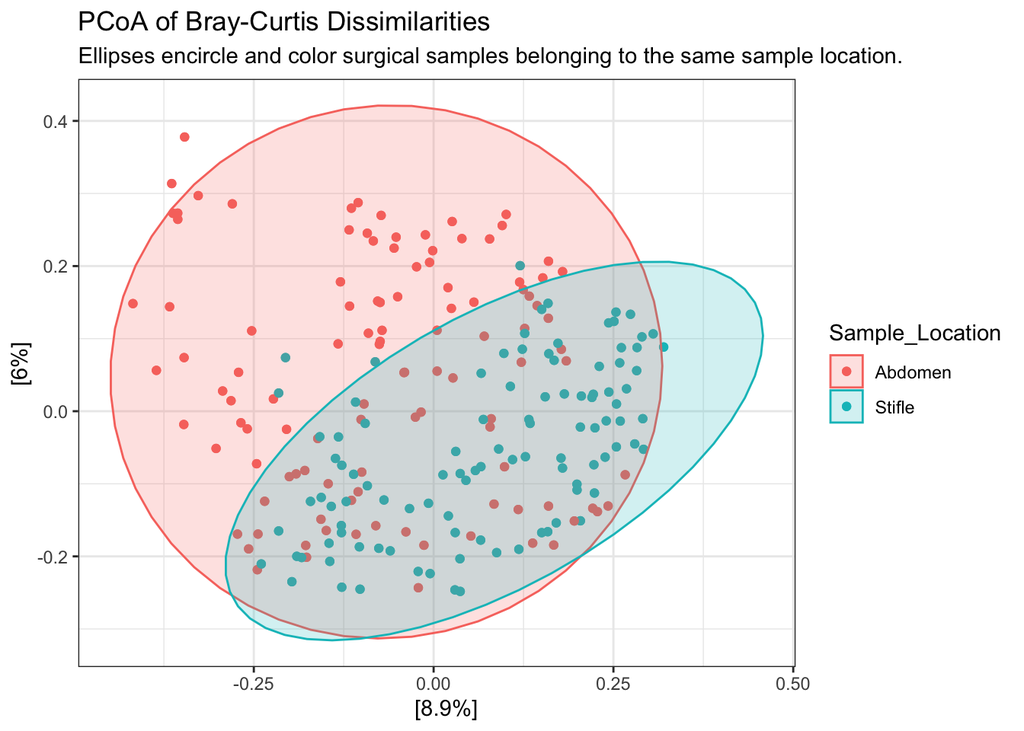

```r
# Keep only surgical samples
surgical_samples <- metadata %>%
  filter(Sample_Site == "Surgical") %>%
  distinct(Individual, Day_Order, SampleID)

surgical_sample_data <- metadata %>%
  inner_join(surgical_samples, by = c("Individual", "Day_Order", "SampleID"))


# Prune phyloseq object so it only contains these remaining samples
ps_3 <- prune_samples(surgical_sample_data$SampleID, ps_1)

ps_rel_3 <- transform_sample_counts(ps_3, function(x) x / sum(x))
bray_dist <- phyloseq::distance(ps_rel_3, method = "bray")


set.seed(100)
bray_pcoa <- ordinate(ps_rel_3, method = "PCoA", distance =  bray_dist)
p1 <- plot_ordination(ps_rel_3, bray_pcoa, color = "Sample_Location")

p1 + ggtitle("PCoA of Bray-Curtis Dissimilarities", subtitle = "Ellipses encircle and color surgical samples belonging to the same sample location.") +
  geom_point(size = 1.5) +
  theme_bw() +
  stat_ellipse(aes(fill = Sample_Location, group = Sample_Location), alpha = 0.2, geom = "polygon")
```

```r
# PERMANOVA test
set.seed(100)
adonis2(bray_dist ~ Sample_Location + Dog_ID, data = surgical_sample_data, permutations = 999, by = "terms")
```

```
## Permutation test for adonis under reduced model
## Terms added sequentially (first to last)
## Permutation: free
## Number of permutations: 999
##
## adonis2(formula = bray_dist ~ Sample_Location + Dog_ID, data = surgical_sample_data, permutations = 999, by = "terms")
##                  Df SumOfSqs      R2       F Pr(>F)
## Sample_Location   1    2.775 0.03593 10.2398  0.001 ***
## Dog_ID           18   21.887 0.28337  4.4867  0.001 ***
## Residual        194   52.577 0.68070
## Total           213   77.240 1.00000
## ---
## Signif. codes:  0 '***' 0.001 '**' 0.01 '*' 0.05 '.' 0.1 ' ' 1
```

### Taxa Relative Abundances in Stifle Groups

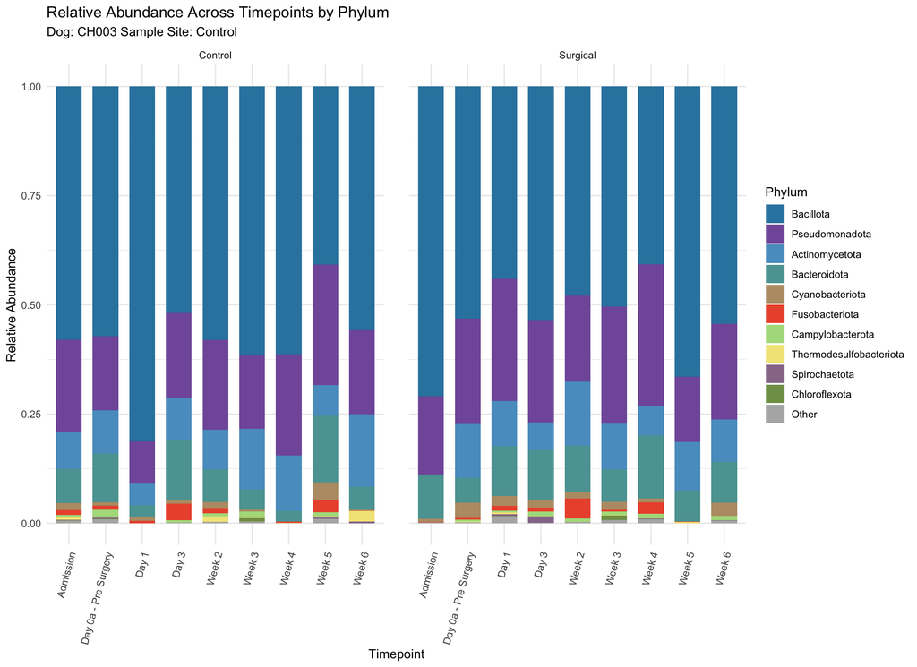

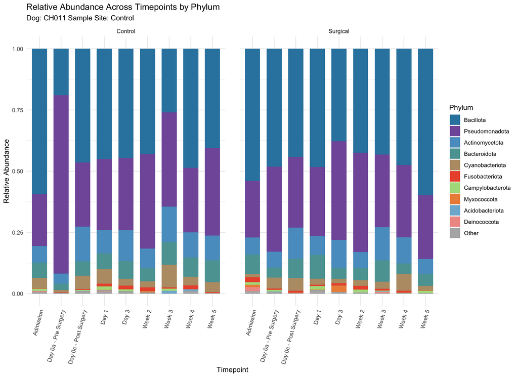

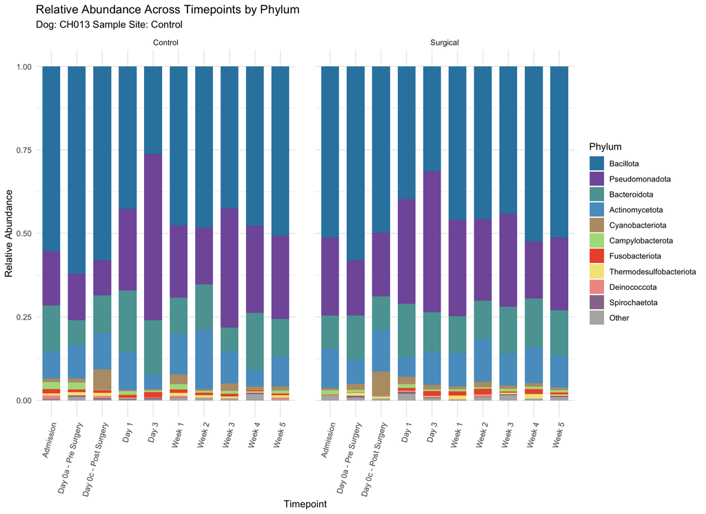

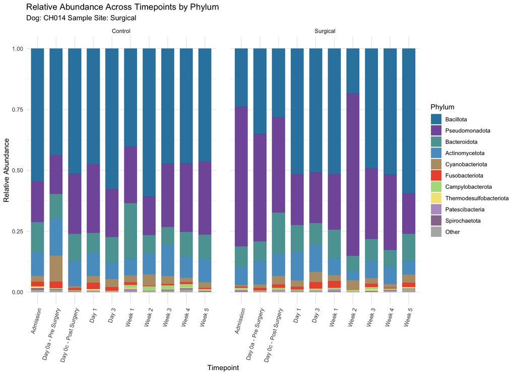

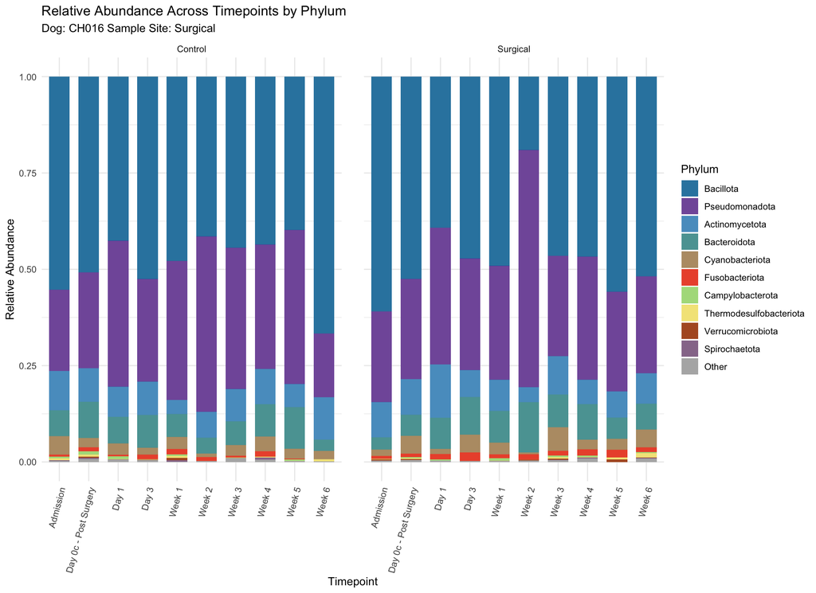

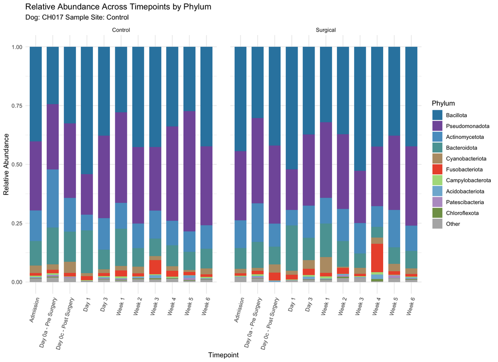

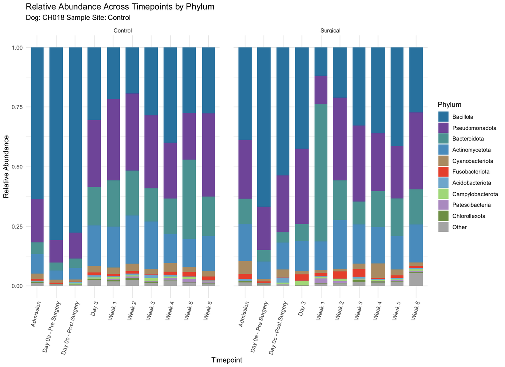

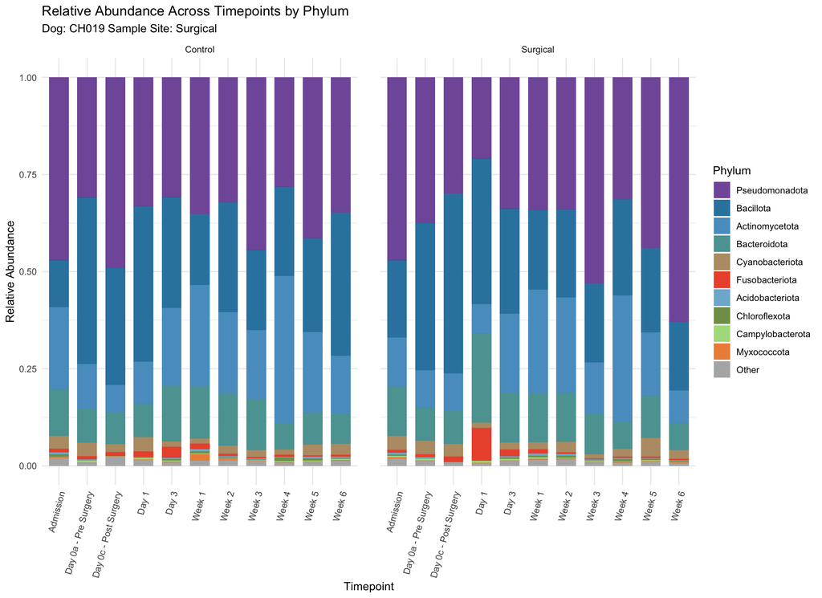

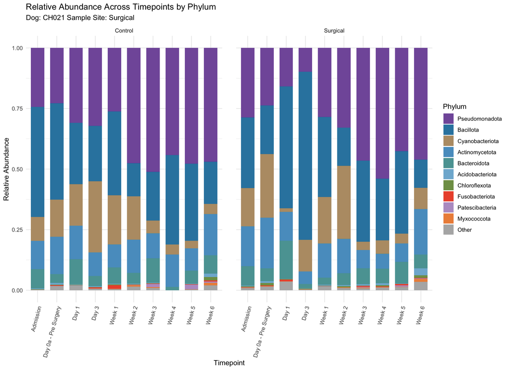

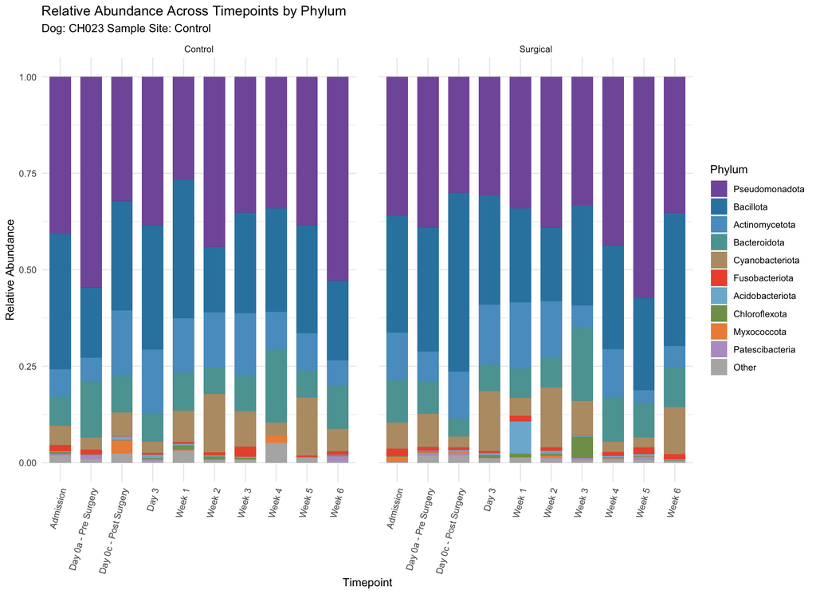

```r
individual_list <- unique(as.data.frame(as(sample_data(ps_rel_2), "data.frame"))$Individual[sample_data(ps_rel_2)$Surgery_Type == "Stifle"])

# create color palette so phyla is the same color across all individual dog plots
all_phyla <- tax_table(ps_rel_2)[, "Phylum"] %>% as.vector() %>% unique() %>% na.omit() %>% sort()
n_phyla <- length(all_phyla)
base_cols <- brewer.pal(min(n_phyla, 12), "Paired")
phylum_cols_vec <- colorRampPalette(base_cols)(n_phyla)
phylum_colors <- setNames(phylum_cols_vec, all_phyla)

# Generate per dog plots showing (top 10) phyla diversity across timepoints
for (ind in individual_list) {
  ps_ind <- subset_samples(ps_rel_2, Individual == ind)
    plot_df <- psmelt(ps_ind) %>%
    filter(Sample_Site %in% c("Control", "Surgical"))

  # Identify top 10 phyla specific to this dog's profile
  top20_ind <- plot_df %>%
    group_by(Phylum) %>%
    summarise(Total_Abundance = sum(Abundance), .groups = "drop") %>%
    arrange(desc(Total_Abundance)) %>%
    slice_head(n = 10) %>%
    pull(Phylum)

  phylum_levels_ind <- c(top20_ind, "Other")

  plot_df <- plot_df %>% mutate(
    Phylum = ifelse(Phylum %in% top20_ind, Phylum, "Other"),
    Phylum = factor(Phylum, levels = phylum_levels_ind),
    Sample_Site = factor(Sample_Site, levels = c("Control", "Surgical")),
    Day_Order = factor(Day_Order)
  )

  local_cols <- phylum_colors[top20_ind]
  missing_indices <- is.na(local_cols)
  if(any(missing_indices)) {
    fallback_pool <- brewer.pal(12, "Paired")
    local_cols[missing_indices] <- sample(fallback_pool, sum(missing_indices), replace = TRUE)
  }
  values_ind <- c(local_cols, "Other" = "grey70")

  p <- ggplot(plot_df, aes(x = Day_Order, y = Abundance, fill = Phylum)) +
    geom_col(position = "stack", width = 0.7) +
    facet_wrap(~Sample_Site, nrow = 1) +
    scale_fill_manual(
      values = values_ind,
      breaks = phylum_levels_ind,
      na.value = "black"
    ) +
    theme_minimal() +
    theme(
      axis.text.x = element_text(angle = 75, hjust = 1),
      panel.spacing = unit(1.5, "lines")
    ) +
    labs(
      title = paste0("Relative Abundance Across Timepoints by Phylum"),
      subtitle = paste0("Dog: ", ind, " Sample Site: ", unique(plot_df$Sample_Site)),
      x = "Timepoint",
      y = "Relative Abundance"
    )
  print(p)
}
```